# The Daily Grind

Sumit Gupta, Kavita Deodhar

## Overview

Social Media is a daily diary for many people. It is now easy to let your voice be heard even if it is about a simple thing like our regular cup of coffee. There are many options and people tend to be loyal to their brands. The intent is to explore which brand do people favor based on their tweets. We would like to show how data could provide highly useful insights about the business. By harnessing the power of data companies can provide better service to the customers. It could also be used to see how a company could expand their presence. Also the intent is to explore whether momentary emotion conveyed via a tweet has any correlation on customer satisfaction index. We will compare CSAT data from ACSI(American customer satisfaction index) to the scores generated using our code.

For the purpose of this project we are going to use the following brands.

[figure not shown]

[figure not shown]

[figure not shown]

[figure not shown]

[figure not shown]

## Initial Questions

Here’s what would like to learn and accomplish: 1. Perform sentiment analysis on twitter data for various coffee shop brands and determine which brand is most favored. 2. Does brand preference change in different parts of the country? 3. Perform regression analysis and determine if emotion expressed on twitter ties into/affects/compares to customer satisfaction index calculated using multivariate customer experience data. 4. We would like to see if there is a trend (plot against time) but we may not be able to do it due to the size of data. 5.Check if the ACSI index values are close to the tweet scores.

## Data and Exploratory Analysis

Let us start analysis by gathering twitter data for the above brands. We will be using Twitter API for this purpose.

Considering the fact that most people may exclusively communicate using emojis, we decided not to drop emojis out of our analysis.Source of this data is “https://raw.githubusercontent.com/today-is-a-good-day/Emoticons/master/emDict.csv”

In order to extract geocode information from tweets, we used following cities and surrounding areas within a 200 mile radius within our search criteria : DC,New York,San Fransisco,Colorado,Mountainview,Tampa,Austin,Boston,Seatle,Vegas,Atlanta,Raleigh,Chicago,Los Angeles,Dallas.

```
[1] "Using direct authentication"
```

First we create data sets for each of the individual brands and replace the emojis.

## Plotting data on US map

As the first part of our analysis,we are going to map all the tweets based on the geo code on US map. This is an attempt to analyze brand preferance per region.

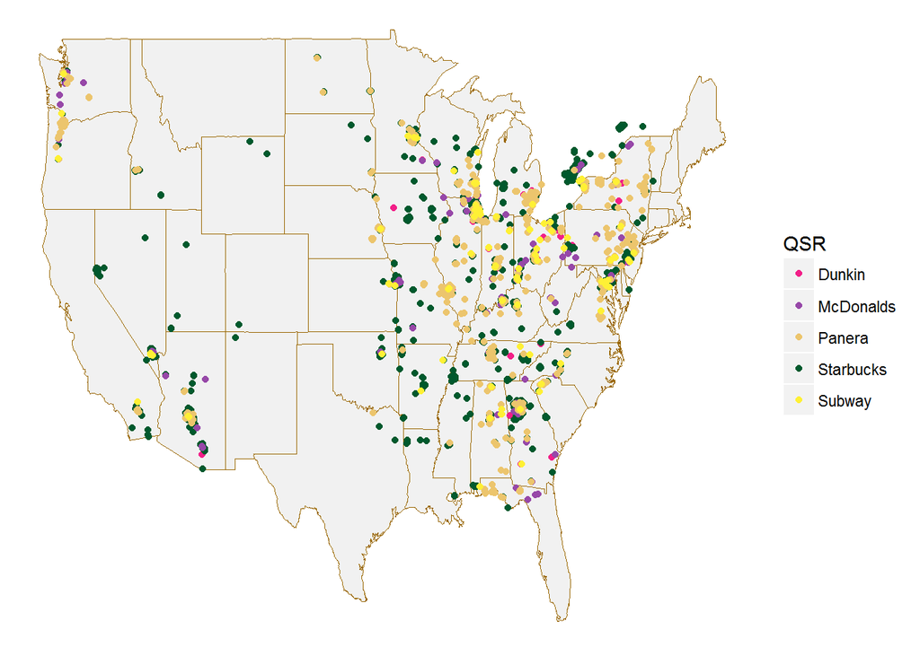

## Cleaning the data

#### Using the tm package to clean the tweets.

Next we proceed with cleaning the data before calculating the score for every tweet.This includes removing special characters, punctuations, words like http, https.

## Calculating tweet scores for all brands.

We will use the nrc sentiment categories.The get_nrc_sentiment implements Saif Mohammad’s NRC Emotion lexicon. According to Mohammad, “the NRC emotion lexicon is a list of words and their associations with eight emotions (anger, fear, anticipation, trust, surprise, sadness, joy, and disgust) and two sentiments (negative and positive)” (See http://www.purl.org/net/NRCemotionlexicon). The get_nrc_sentiment function returns a data frame in which each row represents a sentence from the original file. Source of the above information is “https://cran.r-project.org/web/packages/syuzhet/vignettes/syuzhet-vignette.html”

## Sentiment per brand

Below is the plot of number of tweets per brand per category.It helps is understand the general emotion for each brand and also per category for every brand.

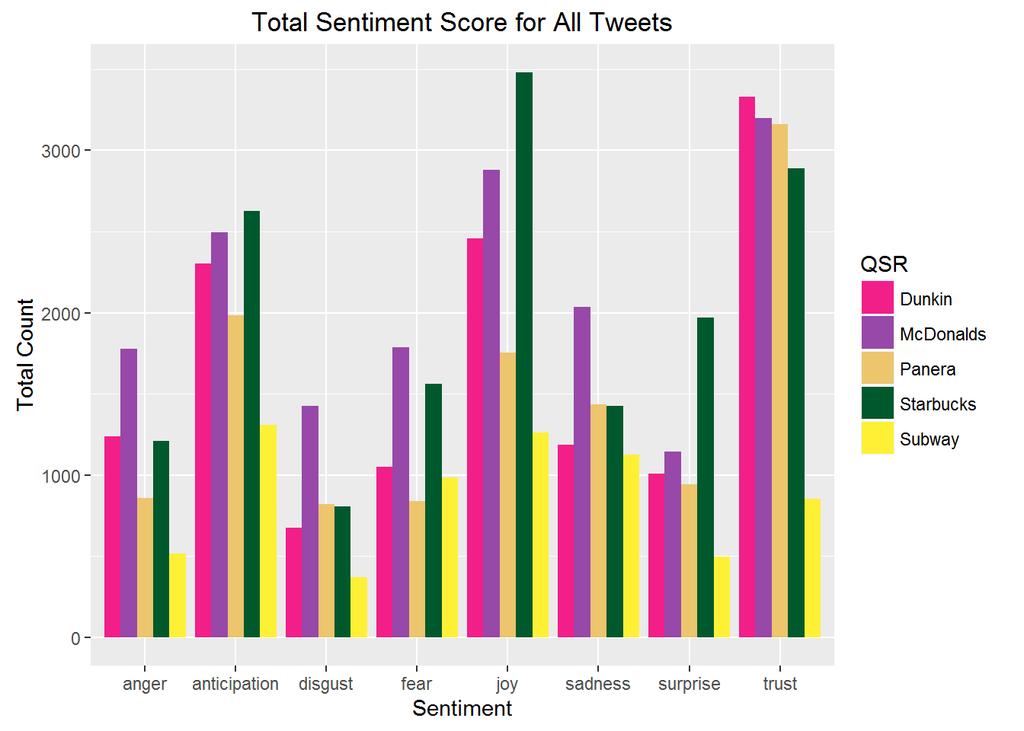

Dunkin seems to be the brand people trust the most and Starbucks gives most joy to people.There also is a lot of negative emotion for McDonalds.Tweets about Subway and Panera seem to be spread equally over all categories of emotion.

The categories of sentiments are fine, but what are those words that people associate with these brands? What is it that people are talking about in regards to the brands?

Word cloud helps us do just that. Below are the word clouds for all the 5 of our brands. Note that the font is largest for the most popular word and decreases as the frequency decreases.

[figure not shown]

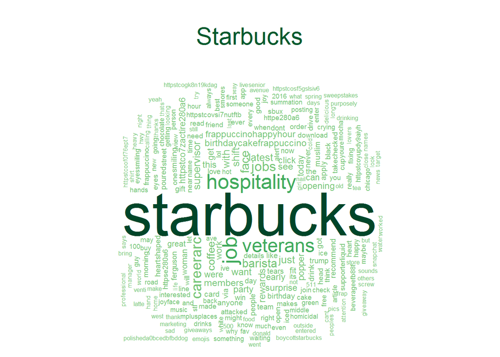

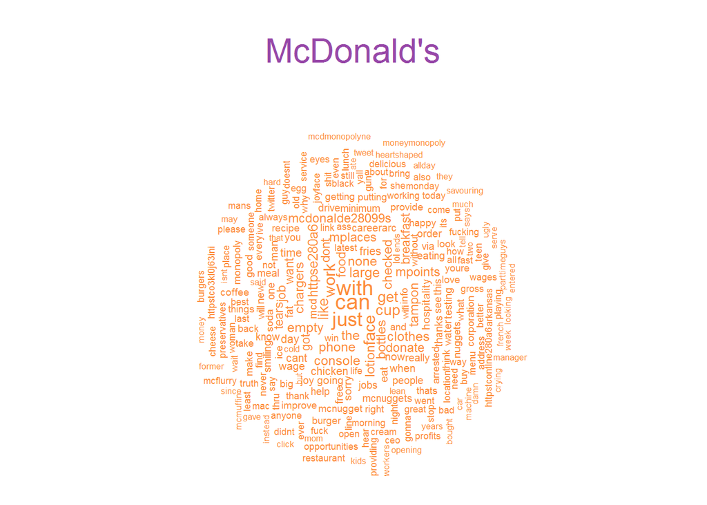

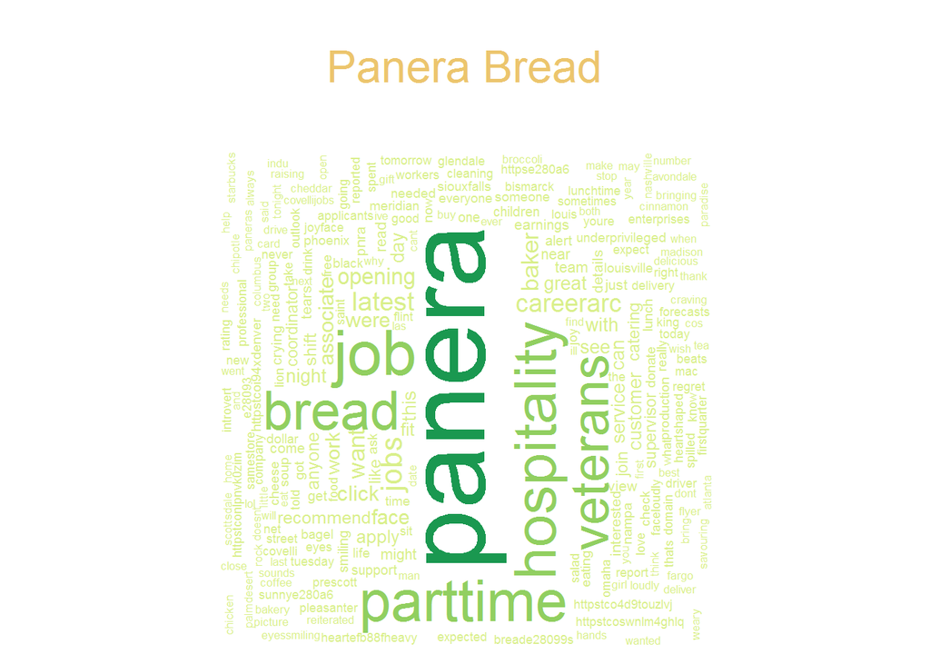

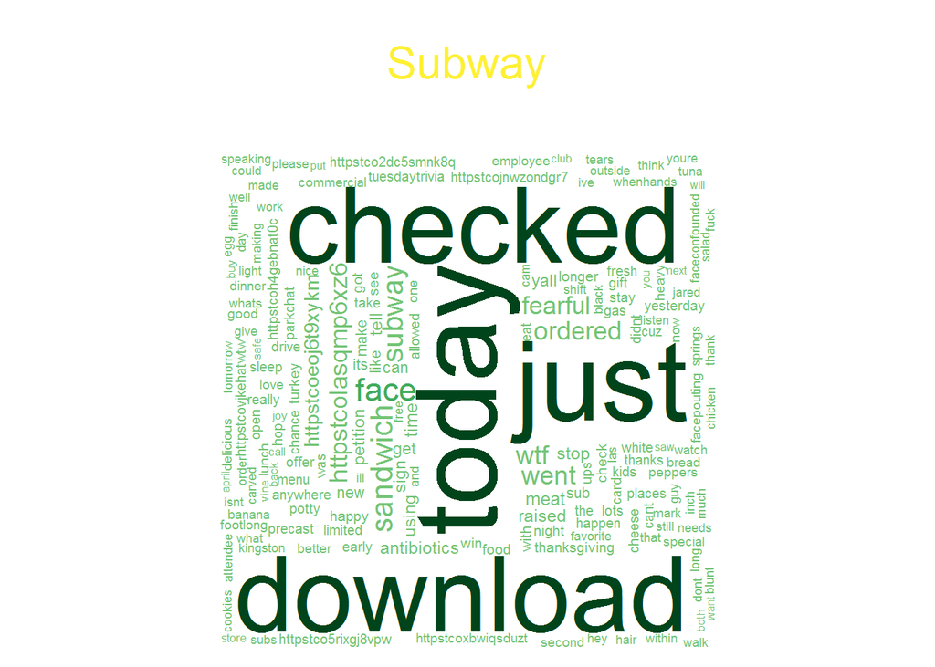

The most used words will change through out the course of the day as more tweets are added from the new day and old ones removed.

We have been able to gather tweets only for a ceratin number of days due to restrictions on the Twitter API. So we cannot see the trend of sentiment over years or months. However we will calculate and plot negative and positive sentiment over the last few days for all the brands.

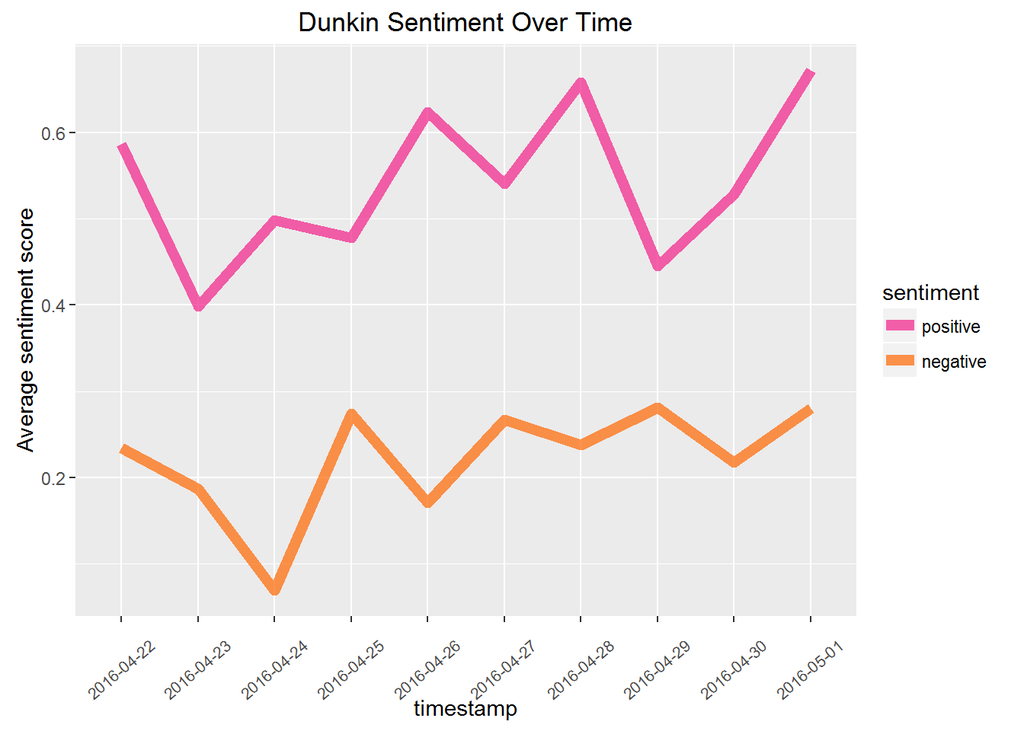

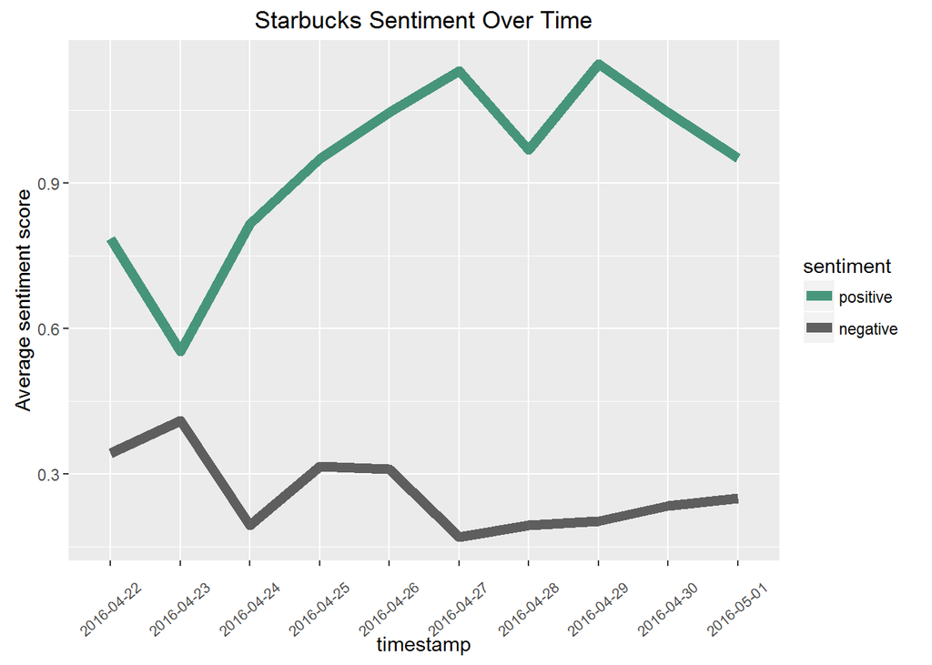

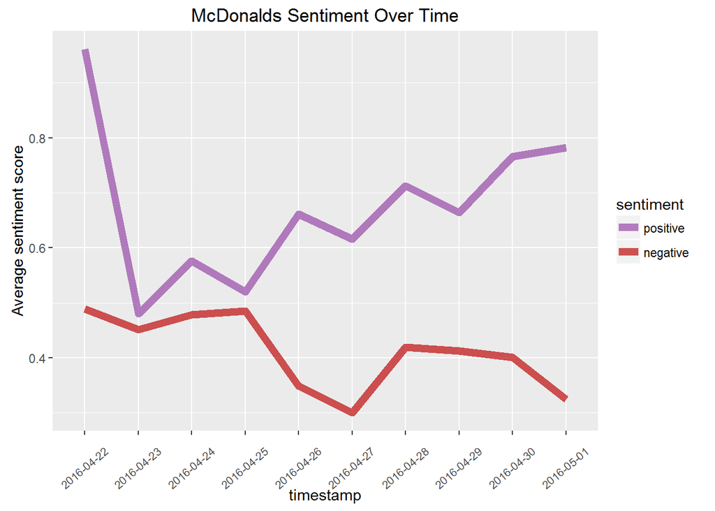

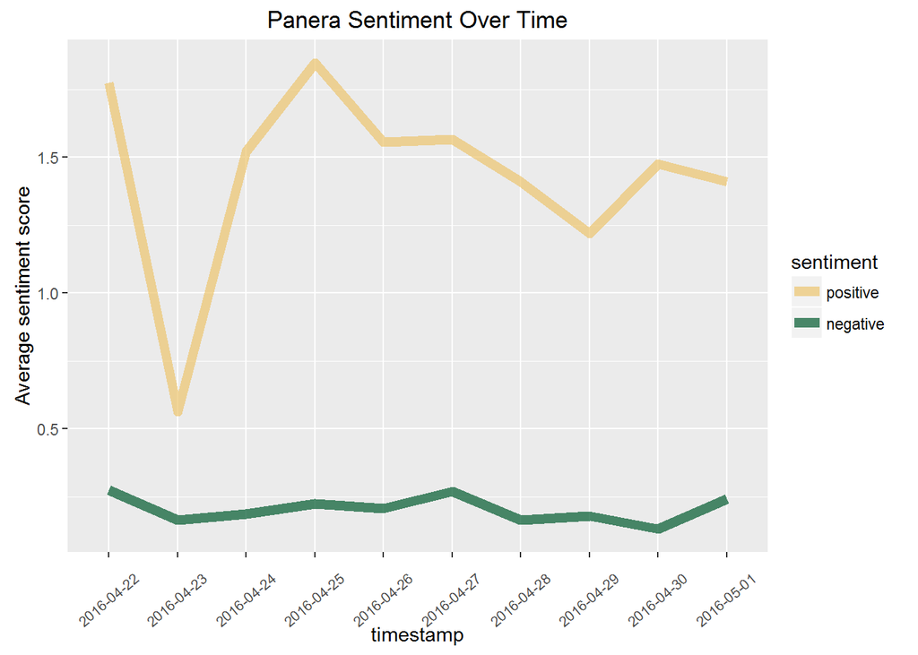

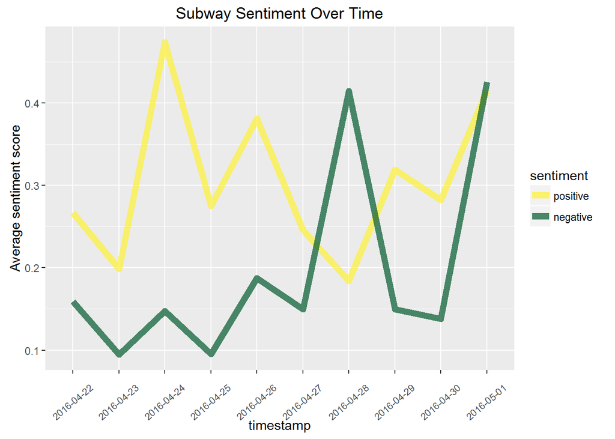

## Comparing the distribution of scores.

Next step would be to check the distribution of scores or sentiments. The difference between the positive and negative scores will give the general tweet sentiment or score. negative value will indicate negative sentiment and positive value will contain positive sentiment.

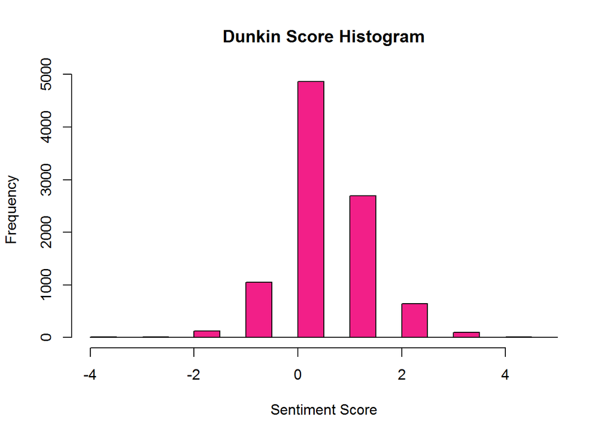

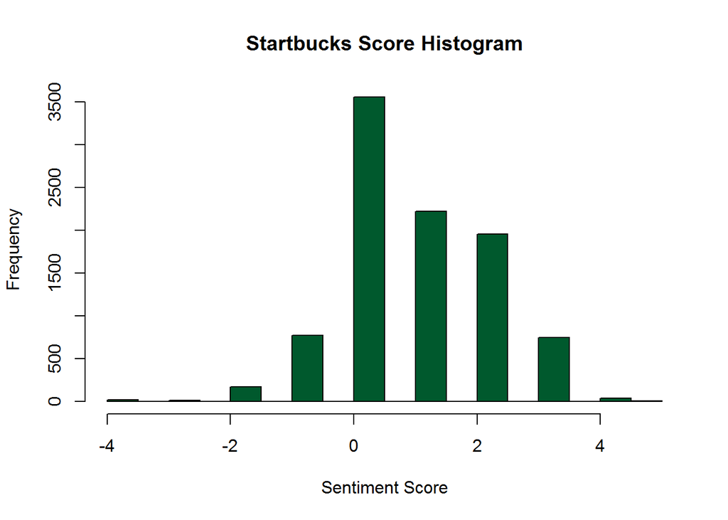

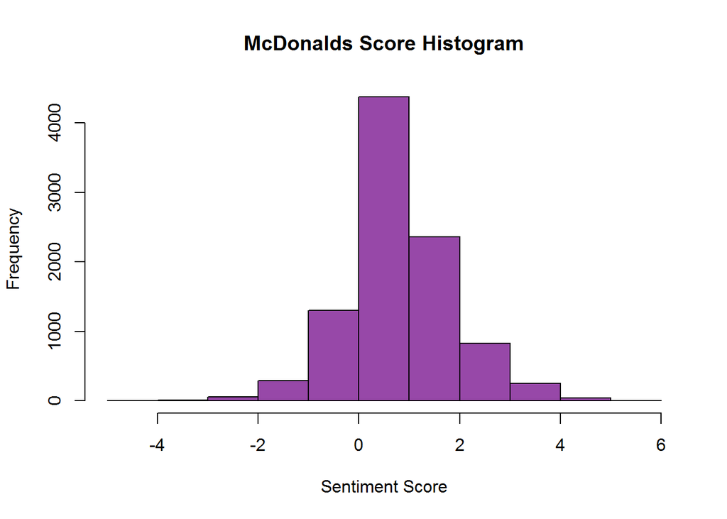

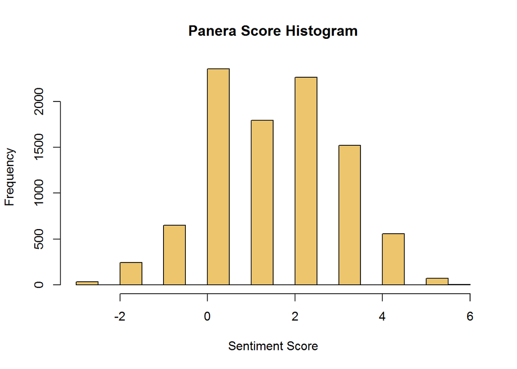

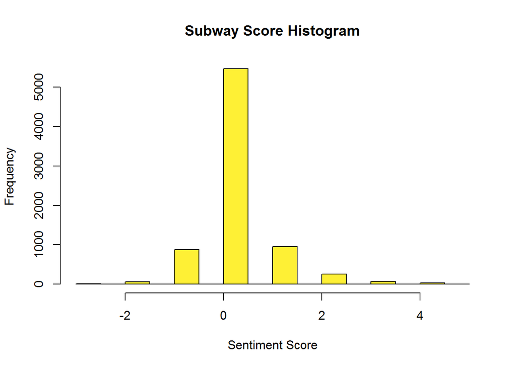

## Compare with ACSI data.

The customer satisfaction (ACSI) index score is calculated as a weighted average of three survey questions that measure different facets of satisfaction with a product or service. ACSI researchers use proprietary software technology to estimate the weighting for each question.Source of this information is “http://www.theacsi.org”

The last step is to compare the average tweet score(calculated for tweets in our dataset which are over a period of few days only) for all our brands with the ACSI index score which is determined as described above.

```
Source: local data frame [5 x 3]

        QSR total_pos_pc average_csat
      (chr)        (dbl)        (dbl)
1 Starbucks     81.05619         76.5
2    Dunkin     70.29444         78.0
3 McDonalds     63.90325         71.0
4    Panera     88.40371         80.0
5    Subway     59.90047         80.0
```

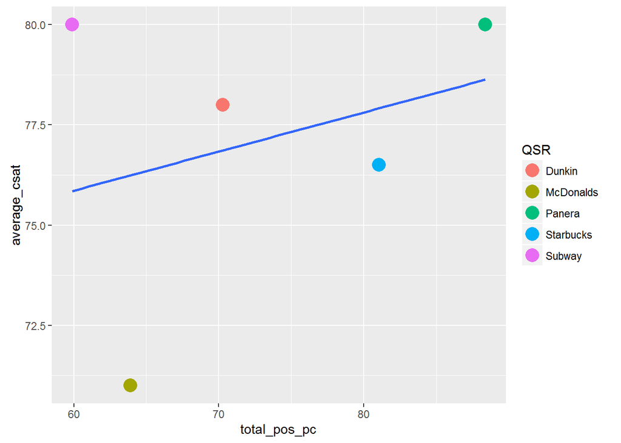